# POLÍTICAS PÚBLICAS E O EXTRATIVISMO VEGETAL NO BRASIL

2022-10-04

## Resumo

A POLÍTICA DE GARANTIA DOS PREÇOS MÍNIMOS DOS PRODUTOS DA SOCIOBIODIVERSIDADE (PGPM-Bio) é uma iniciativa estatal que visa subsidiar o extrativista de produtos vegetais sempre que o preço dos produtos de sua coleta atingirem valores inferiores ao preço mínimo estipulado anualmente em portaria ministerial. A política tem por objetivo garantir renda mínima ao extrativista, de modo que este seja estimulado a continuar na atividade extrativa de modo sustentável e, assim, zelar pela preservação das espécies da sociobiodiversidade. Este artigo correlacionar a intervenção com o aumento da produção.

## Quadro 1 – Evolução normativa

| Ano | Normativo | Descrição |
| --- | --- | --- |
| 1990 | Lei nº 8.029, de 12/04/1990 | Criação da Companhia Nacional de Abastecimento (Conab), originária da fusão da Companhia de Financiamento da Produção (CFP), Companhia Brasileira de Armazenamento (Cibrazem) e da Companhia Brasileira … |
| 1991 | Lei nº 8.171, de 17/01/1991 | Definidos os fundamentos e objetivos da política agrícola |
| 1992 | Lei nº 8.427, de 27/05/1992 | Dispõe sobre a concessão de subvenção econômica nas operações de crédito rural a produtores rurais e suas cooperativas. |
| 2002 | Decreto nº 4.339, de 22/09/2002 | Ficam instituídos, conforme o disposto do Anexo do Decreto, os princípios e diretrizes para a implementação, na forma da lei, da Política Nacional da Biodiversidade, com a participação dos governos fe… |
| 2003 | Resolução Bacen nº 3.083, de 25/06/2003 | Instituída a Linha Especial de Comercialização (LEC) para os produtos amparados pela PGPM, sendo em 2012, por intermédio da Resolução Bacen nº 4.106, de 28 de junho, substituída pelo Financiamento Esp… |
| 2006 | Lei nº 11.326, de 24/07/2006 | Estabelece as diretrizes para a formulação da Política Nacional da Agricultura Familiar e Empreendimentos Familiares Rurais. |

Fonte: Diário Oficial da União

## Gráfico Valor da Intervenção

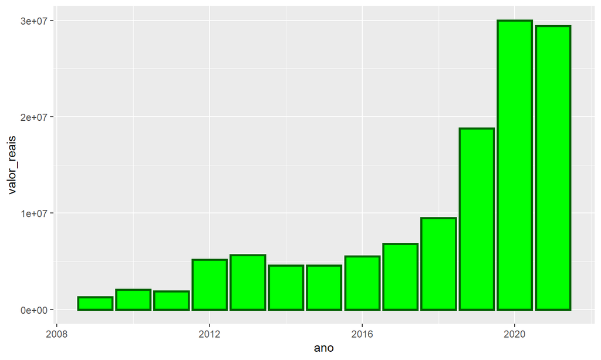

## Gráfico Volume da intervenção

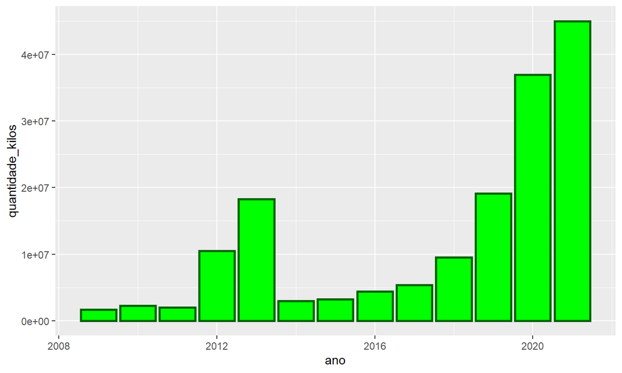

## Dados da PEVS/IBGE - Produção extrativa de PFNM

Os principais produtos florestais não madeireiros (PFNM) constituem a pesquisa PEVS/IBGE obtida atraves do pacote Sidrar:

```r
dados_extrativismo <- sidrar::get_sidra(289, variable = "allxp", period = "all", geo = "Brazil",
geo.filter = NULL, classific = "all", category = "all", header = TRUE,
format = 4, digits = "default", api = NULL)

names(dados_extrativismo)[13] <- 'Tipo'
```

## Gráfico Volume e Valor da produção

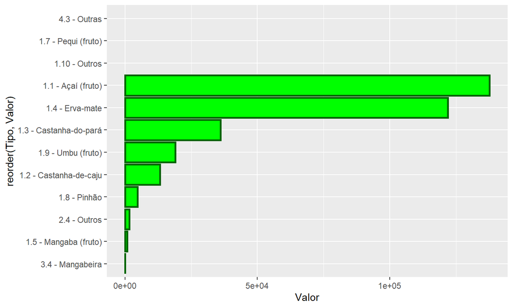

## Método: Regressão entre Intervenção e Produção

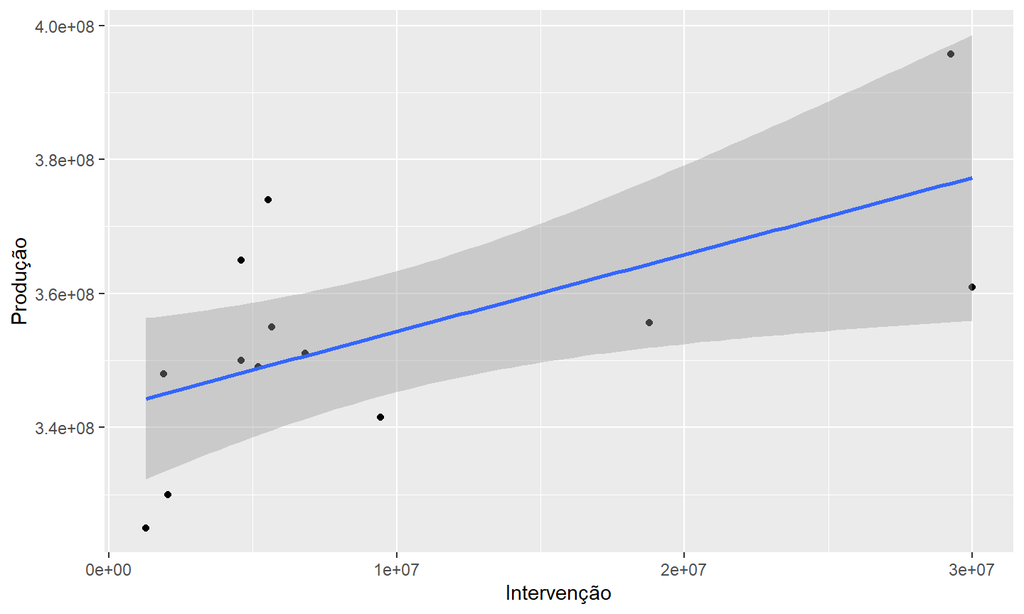

## Correlação

Conforme gráfico anterior, estabeleceremos a correlação entre as variáveis, com o pacote corrplot

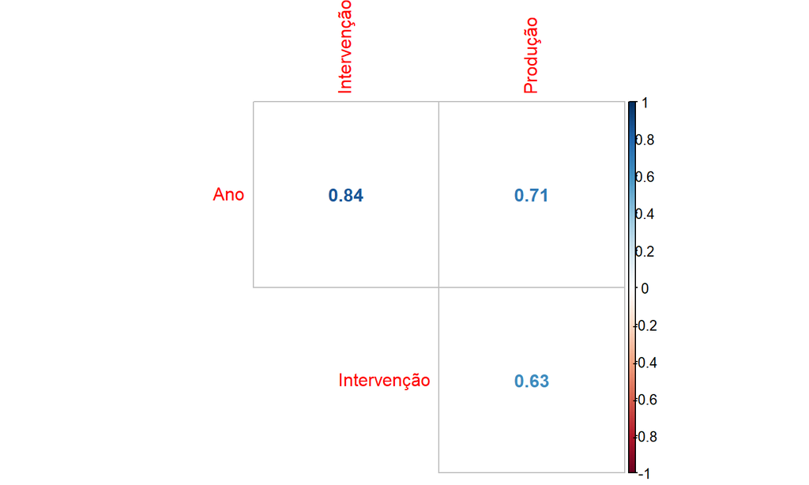

## Modelo

Seguindo o modelo estabalecido, fazemos a regressão da produção em relação à intervenção.

```
##
## Call:
## stats::lm(formula = Produção ~ Intervenção, data = .)
##
## Residuals:
##       Min        1Q    Median        3Q       Max
## -19322504 -12184051    347700   5658887  24738118
##
## Coefficients:
##              Estimate Std. Error t value Pr(>|t|)
## (Intercept) 3.429e+08  5.828e+06  58.832 4.23e-15 ***
## Intervenção 1.148e+00  4.302e-01   2.668   0.0219 *
## ---
## Signif. codes:  0 '***' 0.001 '**' 0.01 '*' 0.05 '.' 0.1 ' ' 1
##
## Residual standard error: 14790000 on 11 degrees of freedom
## Multiple R-squared:  0.3929, Adjusted R-squared:  0.3377
## F-statistic: 7.119 on 1 and 11 DF,  p-value: 0.02186
```

## Considerações Finais

Tal fato revela a baixa relevância da PGPMBio em influenciar a oferta de produtos nativos e garantir complemento de renda a seus beneficiários, considerando todos aqueles que deveriam ser atendidos e os efeitos positivos que política produz para aqueles que conseguem acessá-la.

## continuação final

O estímulo à proteção ambiental também fica restrito a poucos produtores que recebem o incentivo. Sendo assim, dada a baixa abrangência, não é possível afirmar que esse instrumento alcance objetivos em níveis nacionais. Porém, se aproxima da eficácia quando a análise se restringe àqueles que acessam o instrumento, como já exposto. Portanto, a restrita abrangência do instrumento pode ser ressaltada como o maior entrave para o cumprimento pleno dos objetivos da política. A intervenção estatal no mercado de produtos da sociobiodiversidade, como um todo, apenas será eficaz se o instrumento utilizado chegar a maior parte dos seus beneficiários potenciais e forem colhidos dados de maneira sistemática de modo a possibilitar seu acompanhamento e o direcionamento dos recursos, na medida em que as cadeias produtivas demonstrem necessidade.